# Part I - Communicate Data Findings Project

## Bivarate Exploration

```python
bike.head(4)
```

|  | duration_sec | start_time | end_time | start_day_of_week | time_of_day | month | start_station_id | start_station_name | start_station_latitude | start_station_longitude | ... | end_station_latitude | end_station_longitude | dist | speed | bike_id | user_type | member_birth_year | member_gender | age | bike_share_for_all_trip |
| --- | --- | --- | --- | --- | --- | --- | --- | --- | --- | --- | --- | --- | --- | --- | --- | --- | --- | --- | --- | --- | --- |
| 0 | 75284 | 2018-01-31 22:52:35 | 2018-02-01 19:47:19 | Wednesday | evening | January | 120.0 | Mission Dolores Park | 37.761420 | -122.426435 | ... | 37.783521 | -122.431158 | 2.492254 | 0.119177 | 2765 | Subscriber | 1986 | Male | 32 | No |
| 2 | 71577 | 2018-01-31 14:23:55 | 2018-02-01 10:16:52 | Wednesday | afternoon | January | 304.0 | Jackson St at 5th St | 37.348759 | -121.894798 | ... | 37.325998 | -121.877120 | 2.974502 | 0.149604 | 3039 | Customer | 1996 | Male | 22 | No |
| 3 | 61077 | 2018-01-31 14:53:23 | 2018-02-01 07:51:20 | Wednesday | afternoon | January | 75.0 | Market St at Franklin St | 37.773793 | -122.421239 | ... | 37.780955 | -122.399749 | 2.049710 | 0.120814 | 321 | Customer | 0 | NaN | 0 | No |
| 4 | 39967 | 2018-01-31 19:52:24 | 2018-02-01 06:58:31 | Wednesday | evening | January | 74.0 | Laguna St at Hayes St | 37.776435 | -122.426244 | ... | 37.788975 | -122.403452 | 2.440571 | 0.219833 | 617 | Subscriber | 1991 | Male | 27 | No |

4 rows × 22 columns

### Relationship between user_type and duration_sec

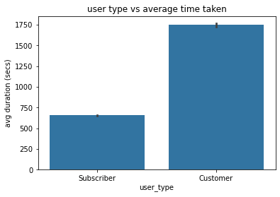

```python
# relation via mean

sb.barplot(data = bike , y= 'duration_sec' , x= 'user_type', color = color);
plt.ylabel('avg duration (secs)')
plt.title('user type vs average time taken')
plt.show()
```

> The plot shows that the **customers** have the highest mean trip time/ duration , am going to check the total time and compare.

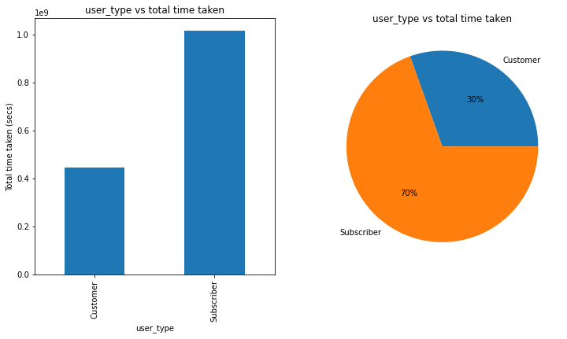

```python
# relation via sum

group_user = bike.groupby('user_type')[['duration_sec', 'dist']].sum()

plt.figure(figsize = (12,6))
plt.subplot(1,2,1)

group_user['duration_sec'].plot(kind='bar')
plt.ylabel('Total time taken (secs)')
plt.title('user_type vs total time taken')

plt.subplot(1,2,2)
group_user['duration_sec'].plot(kind ='pie',autopct='%.0f%%')
plt.ylabel('')
plt.title('user_type vs total time taken');
```

> The sum barplot shows that subscribers had a combined higher trip duration.

### Relationship between user_type and distance

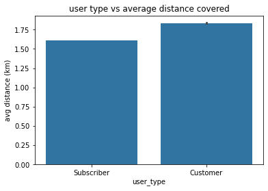

```python
# relation via mean

sb.barplot(data = bike , x = 'user_type' , y ='dist' ,color = color)
plt.title('user type vs average distance covered')
plt.ylabel('avg distance (km)');
```

> Not only do the customers have the higher mean trip time/duration , but also covered a higher mean distance ,I will check the sum.

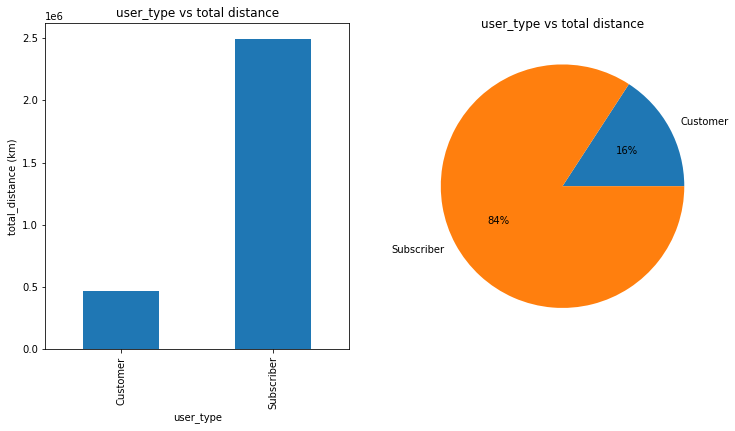

```python
# relation via sum

plt.figure(figsize = (12,6))
plt.subplot(1,2,1)
group_user['dist'].plot(kind ='bar')
plt.ylabel('total_distance (km)')
plt.title('user_type vs total distance')

plt.subplot(1,2,2)
group_user['dist'].plot(kind ='pie',autopct='%.0f%%')
plt.ylabel('')
plt.title('user_type vs total distance');
```

> In terms of sum , the subscribers covered a greater total distance than the customers.

### Relationship between age and member_gender

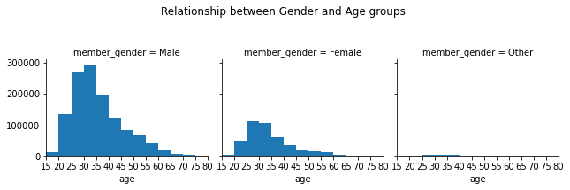

```python
g = sb.FacetGrid(data = bike , col = 'member_gender')
g.map(plt.hist, 'age' ,bins = bins)
g.set(xlim = (15,80) , xticks = np.arange(15, 80 +5,5))
g.fig.subplots_adjust(top=0.7)
g.fig.suptitle('Relationship between Gender and Age groups');
```

> In the **male** category, age group 30 -35 had the most trip

> In the **female** category , age group 25 -30 had the most trip. The plot also seems bimodal.

> In the **other** category , age group 25 -45 had the most trip.

### What's the relationship between member_gender and distance / duration_sec?

#### mean

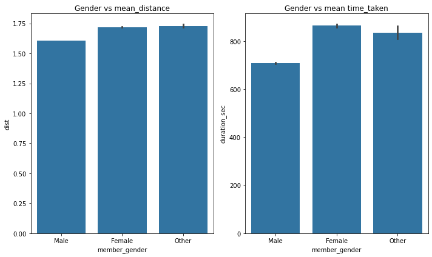

```python
# relationship via mean

plt.figure(figsize = (10,6))

plt.subplot(1,2,1)
sb.barplot(data = bike , x = 'member_gender' , y ='dist' ,color = color)
plt.title('Gender vs mean_distance')

plt.subplot(1,2,2)
sb.barplot(data = bike , x = 'member_gender' , y ='duration_sec' ,color = color)
plt.title('Gender vs mean time_taken')

plt.tight_layout()
plt.show()
```

#### sum

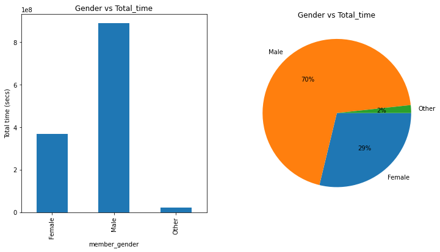

```python
# sum of duration (secs)
group_gender = bike.groupby('member_gender')[['duration_sec', 'dist']].sum()

plt.figure(figsize =(12,6))

plt.subplot(1,2,1)
group_gender['duration_sec'].plot(kind = 'bar')
plt.ylabel('Total time (secs)')
plt.title('Gender vs Total_time')

plt.subplot(1,2,2)
group_gender['duration_sec'].plot(kind ='pie',autopct='%.0f%%', counterclock =False)
plt.ylabel('')
plt.title('Gender vs Total_time')


plt.show()
```

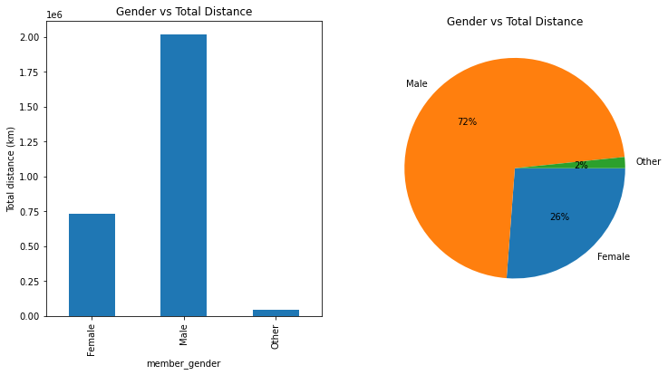

```python
# sum of distance (km)
plt.figure(figsize =(12,6))

plt.subplot(1,2,1)
group_gender['dist'].plot(kind = 'bar')
plt.ylabel('Total distance (km)')
plt.title('Gender vs Total Distance')

plt.subplot(1,2,2)
group_gender['dist'].plot(kind ='pie',autopct='%.0f%%', counterclock =False)
plt.ylabel('')
plt.title('Gender vs Total Distance');
```

> In terms of mean , the **Other** gender had the highest average (mean) trip distance. The **Female** gender had the highest avg (mean) trip time/ duration.

> In terms of sum , the **Male** gender had highest the combined trip time / distance.

### What month of the year has the highest total distance travelled?

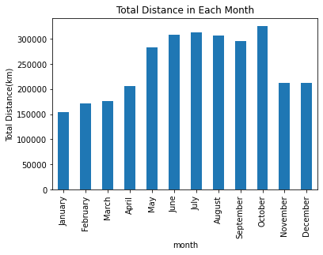

```python
# make month categorical
cat_month = bike['month'].unique()

c = pd.api.types.CategoricalDtype(categories = cat_month, ordered =True)
bike['month'] = bike['month'].astype(c)


group_year =bike.groupby('month')['dist'].sum()
group_year.plot(kind='bar')
plt.ylabel('Total Distance(km)')
plt.title('Total Distance in Each Month');
```

> The month of October has the highest total distance travelled

### Relationship between age and speed

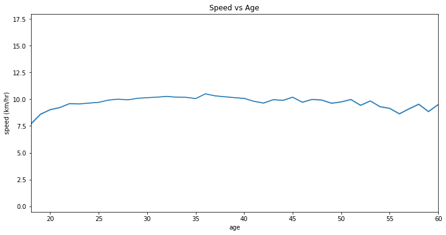

```python
plt.figure(figsize = (12,6))
sb.lineplot(data =bike , x = 'age', y = 'speed')
plt.xlim(18, 60)
plt.title('Speed vs Age')
plt.ylabel('speed (km/hr)');
```

> The speed peaks between riders of ages 35 - 40, and then slowly decreases this could be because the old are weaker than the young. i'll check the time taken for each age group next to compare.

### Relationship between age and duration_sec

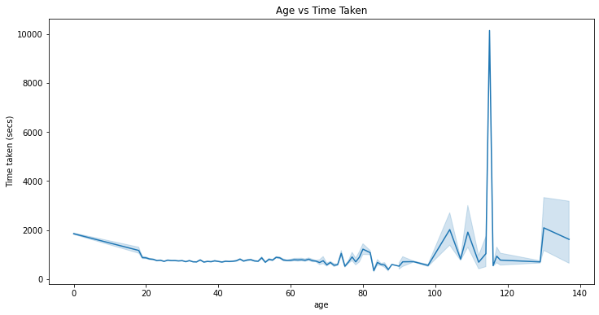

```python
plt.figure(figsize = (12,6))
sb.lineplot(data =bike , x = 'age', y = 'duration_sec')
plt.title('Age vs Time Taken')
plt.ylabel('Time taken (secs)');
```

### Relationship between gender and speed

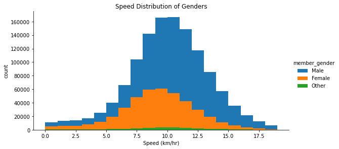

```python
# facetplot
j = sb.FacetGrid(data = bike , hue = 'member_gender',height = 4 , aspect =2)
j.map(plt.hist , 'speed', bins = np.arange(0,20,1))
j.add_legend()
plt.ylabel('count')
plt.xlabel('Speed (km/hr)')
plt.title('Speed Distribution of Genders');
```

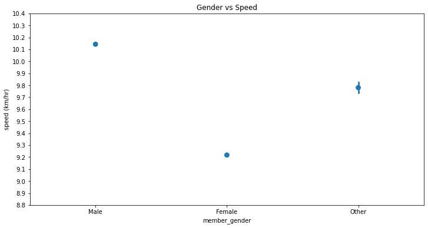

```python
#point plot
plt.figure(figsize = (12,6))

sb.pointplot(data =bike , x = 'member_gender', y = 'speed', linestyles = '')
plt.yticks(np.arange(8.8,10.5, 0.1))
plt.ylabel('speed (km/hr)')
plt.title('Gender vs Speed');
```

> The males achieved a mean speed between 10.1 - 10.2 km/hr

> The females had a mean speed between 9.2 -9.3 km/hr

> The **other** gender had mean speeds between 9.7 - 9.9 km/hr

### Did you observe any interesting relationships between the other features (not the main feature(s) of interest)?

> Because of the nature of the dataset , I only covered the features of interest(almost all columns)

## Multivarate Exploration

### Relationship between gender , distance and month

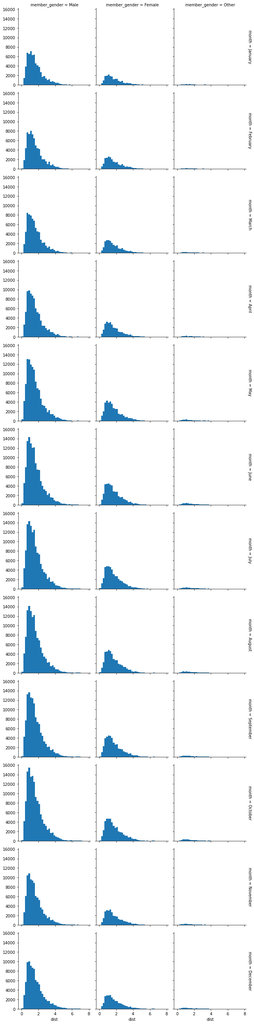

```python
pl = sb.FacetGrid(data = bike , col = 'member_gender', row = 'month' , margin_titles = True)
pl.map(plt.hist , 'dist' , bins = np.arange(0,8,0.2));
```

> Most riders had trips in the month of October.

> Most of these riders were males.

> The month of October has the highest trips by males.

### Relationship between member_gender , user_type and distance(dist)

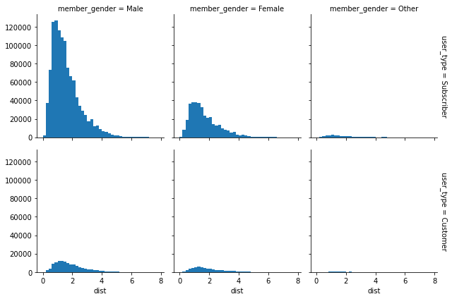

```python
m_u_d = sb.FacetGrid(data = bike , col = 'member_gender' , row = 'user_type' , margin_titles = True)
m_u_d.map(plt.hist , 'dist',bins = np.arange(0,8,0.2));
```

> Most riders were subcibers.

> There is a great distribution of distance covered by subscribers across all genders.

> Most subcribers are males.

> Max distance covered by majority of the riders is less than 2km.

### correlation plot

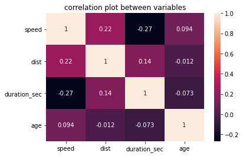

```python
sb.heatmap(bike[['speed','dist', 'duration_sec','age']].corr(), annot = True)
plt.title('correlation plot between variables');
```

### Talk about some of the relationships you observed in this part of the investigation. Were there features that strengthened each other in terms of looking at your feature(s) of interest?

> The investigation shows that most male riders That started their trip in the month of October covered a larger distance than riders in other months, although most of these riders(in the month of October) didn't cover more than 2km.

> Most subscribers were males and covered a larger distance than the customers.

### Were there any interesting or surprising interactions between features?

> I expected the correlation between speed and age to be negative but this might be due to some outliers in the dataset.

## Conclusions

- Most trips started on Tuesday and in the month of October in the afternoon.
- Most of the riders were males (73.5%) and females (24.9%).
- Most riders were between the ages of 25-35 years.
- Most trips were between 1 -2 km
- Male riders covered more distance than other genders. (72%)
- Subscribers had the highest total distance covered and time taken, 84% and 70% respectively.
- Mean speed of riders was approximately 10km/hr.
- Male riders had the highest mean speed of about 10km /hr , followed by the **other** (about 9.9km/hr) and then females (9.2km/hr)
- The elderly (70 -140 years) took longer time to complete their journey.

### References

Towards Data Science